# **One-Way Between-Groups ANOVA**

### **Conditions Required for a Valid Anova F-Test: Completely Randomized Design**

1. The samples are randomly selected in an independent manner from the treatment populations.
2. All k sampled populations have distribution that are approximately normal.
3. The k population variances are equal.

A patient is the experimental unit for this experiment. For a Completely Randomized Design, independent random samples of experimental units are selected for each treatment or k treatments can be randomly assigned to a random sample of experimental units. Our experiment has the latter, since 50 patients were randomly selected and than randomly assigned to treatments. We will consider the first assumption to be fulfilled.

For the second assumption, we can either check the normality of the residuals of our ANOVA model or we can check the normality of each treatment population. The following code uses the function `ggqqplot` function to plot a Q-Q plot of the response variable for each treatment. Looking at the plots, we can see that the k populations are normally distributed.

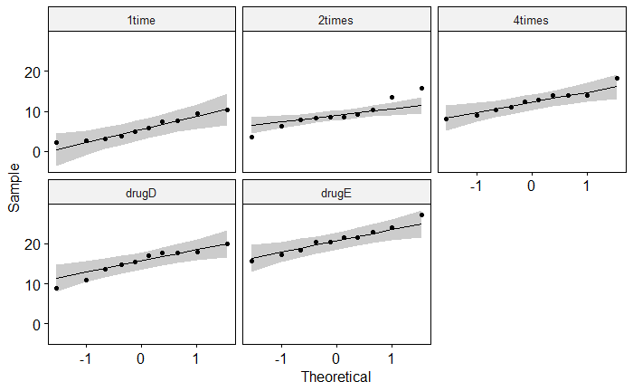

```r
ggqqplot(cholesterol, "response", facet.by = "trt")
```

```r
NA
NA
```

Recall that Anova and Regression are both special cases of the general linear model, which is why we can use the same `lm` function for regression to find the residuals for ANOVA. We can then conduct the Shapiro–Wilk test on the model’s residuals to test for normality. Since the p-value is larger than our significance level(0.05), we do not reject the null hypothesis which means our k treatment populations are most likely normal.

```r
model <- lm(response ~ trt,data = cholesterol)
shapiro.test(model$residuals)
```

```
    Shapiro-Wilk normality test

data:  model$residuals
W = 0.98864, p-value = 0.9094
```

The following code make a Q-Q plot of the above model’s residuals.

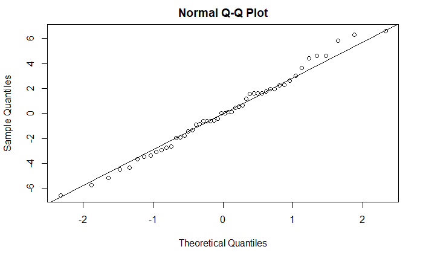

```r
qqnorm(model$residuals)
qqline(model$residuals)
```

```r
NA
NA
```

```r
cholesterol %>%
  group_by(trt) %>%
  summarize(W=shapiro.test(response)$statistic, p_value=shapiro.test(response)$p.value)
```

[output not shown]

The following code does the same thing as the code above but it is a lot cleaner. The `shapiro_test` function is from the package `rstatix` which allows us to use the pipe with statistical tests.

```r
cholesterol %>%
  group_by(trt) %>%
  shapiro_test(response)
```

[output not shown]

Looking at all the code above, we will consider the second assumption to be fulfilled. For the third assumptions we can use Bartlett’s Test of Homogeneity of Variances to find out if the k population variances are equal. We are using Bartlett’s test here instead of Levene’s test because Bartlett’s test performs better when we know that our data is normal. Since the p-value is large for Bartlett’s test, the variances among treatments do not differ significantly.

```r
bartlett.test(response~trt,data = cholesterol)
```

```
    Bartlett test of homogeneity of variances

data:  response by trt
Bartlett's K-squared = 0.57975, df = 4, p-value = 0.9653
```

Outliers inflate the MST and MSE, which leads to a smaller F Statistic. This means that the chance of rejecting the null hypothesis is also lowered. It’s important to make sure there are no data collection errors and to see the effect of outliers on our analysis. Using the `identify_outliers` function allows us to identify outliers using boxplot methods. Looking below, we do not have any extreme outliers so we will keep the data the same.

```r
cholesterol %>%
  group_by(trt) %>%
  identify_outliers(response)
```

[output not shown]

### **Hypotheses for ANOVA F-Test to Compare k Treatment Means**

We will denote the population means of k treatments as u1, u2, u3,… and so on. We will test the null hypothesis that treatment means are equal against the alternative hypothesis that at least two treatment means differ. We will use a level of significance of .05 for this test.

Ho: u1 = u2 = u3 = u4 = u5

Ha: At least two of these treatment means differ.

### **Conducting the Test**

Before we use Tukey’s Method, recall that two independent sample t-tests are equivalent to two independent sample f-tests. Because of this, we can construct a one sample 95% confidence interval for each treatment. If two treatment’s confidence intervals intersect, they are not significantly different.

Why don’t we just conduct multiple t-tests to find the confidence intervals between groups? The problem with this and the approach above is that it increases the likelihood of a Type 1 error. Using Tukey’s method, we can say that collectively 95% of the intervals include the true difference between groups. This is because Tukey’s method adjusts for the amount of groups being compared unlike the t-test.

Looking below, any p-value below our significance level means those two groups are significant different. A 95% confidence interval is also provided which contains the true difference between those groups. For example, we that drugE-drugD has a low p-value meaning they are significantly different. Looking at the ci, we see that the true mean of drugE is (1.48,9.68) higher than drugd.

```r
TukeyHSD(fit)
```

```
  Tukey multiple comparisons of means
    95% family-wise confidence level

Fit: aov(formula = response ~ trt, data = cholesterol)

$`trt`
                  diff        lwr       upr     p adj
2times-1time   3.44300 -0.6582817  7.544282 0.1380949
4times-1time   6.59281  2.4915283 10.694092 0.0003542
drugD-1time    9.57920  5.4779183 13.680482 0.0000003
drugE-1time   15.16555 11.0642683 19.266832 0.0000000
4times-2times  3.14981 -0.9514717  7.251092 0.2050382
drugD-2times   6.13620  2.0349183 10.237482 0.0009611
drugE-2times  11.72255  7.6212683 15.823832 0.0000000
drugD-4times   2.98639 -1.1148917  7.087672 0.2512446
drugE-4times   8.57274  4.4714583 12.674022 0.0000037
drugE-drugD    5.58635  1.4850683  9.687632 0.0030633
```

The following code shows another way to compute tukey’s method for comparing treatments.

```r
pwc <- cholesterol %>% tukey_hsd(response~trt)
pwc
```

|  | term | group1 | group2 | estimate | conf.low | conf.high | p.adj | p.adj.signif |
| --- | --- | --- | --- | --- | --- | --- | --- | --- |
| 1 | trt | 1time | 2times | 3.44300 | -0.6582817 | 7.544282 | 1.38e-01 | ns |
| 2 | trt | 1time | 4times | 6.59281 | 2.4915283 | 10.694092 | 3.54e-04 | *** |
| 3 | trt | 1time | drugD | 9.57920 | 5.4779183 | 13.680482 | 3.46e-07 | **** |
| 4 | trt | 1time | drugE | 15.16555 | 11.0642683 | 19.266832 | 1.35e-12 | **** |
| 5 | trt | 2times | 4times | 3.14981 | -0.9514717 | 7.251092 | 2.05e-01 | ns |
| 6 | trt | 2times | drugD | 6.13620 | 2.0349183 | 10.237482 | 9.61e-04 | *** |
| 7 | trt | 2times | drugE | 11.72255 | 7.6212683 | 15.823832 | 2.27e-09 | **** |
| 8 | trt | 4times | drugD | 2.98639 | -1.1148917 | 7.087672 | 2.51e-01 | ns |
| 9 | trt | 4times | drugE | 8.57274 | 4.4714583 | 12.674022 | 3.72e-06 | **** |
| 10 | trt | drugD | drugE | 5.58635 | 1.4850683 | 9.687632 | 3.06e-03 | ** |

```r
NA
```

The following code visualizes the confidence intervals of differences between group means. If a confidence interval includes 0, those groups are not statistically different from each other.

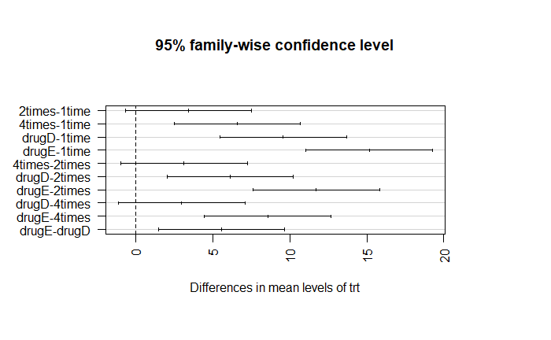

```r
par(las=2,mar = c(7,7,7,7))
plot(TukeyHSD(fit))
```

```r
NA
NA
```

Finally, we use the following code which gives us the boxplots for each treatment along with Tukey’s compact letter ranking. If two boxplots have the same letter, they are not statistically different. Overall, 4times is the best formulation for a certain drug for reducing cholesterol but falls short when compared to the drug E.

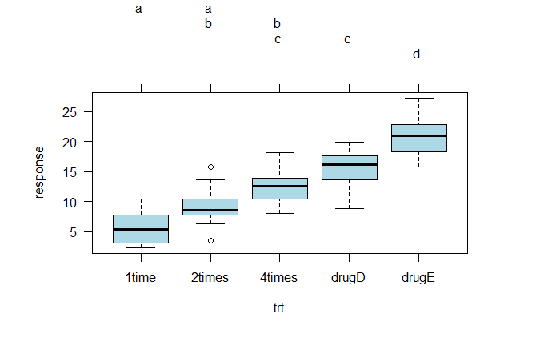

```r
par(las=1,mar=c(6,6,6,6))
tuk <- glht(fit,linfct=mcp(trt="Tukey"))
plot(cld(tuk,level = .05),col = "lightblue")
```